# Saliency Maps

Author

Kris Sankaran

Published

April 6, 2026

*[Readings](https://papers.nips.cc/paper_files/paper/2018/file/294a8ed24b1ad22ec2e7efea049b8737-Paper.pdf)*, *[Code](https://github.com/krisrs1128/stat479_notes/blob/master/notes/13-saliency_handout.qmd)*, *[Conda Env](https://github.com/krisrs1128/stat479_notes/blob/master/notes/stat479_week13.yaml)*

Items marked $^{\dagger}$ are not in the required reading and will not be tested.

## Setup

1. **Goal.** A deep learning classifier $f_{\theta}$ maps a test image $x^\ast$ to class probabilities $\left(f_{\theta,1}(x^\ast), \dots, f_{\theta,K}(x^\ast)\right)$. We want per-pixel importance scores $E\left(x^\ast, f_{\theta}\right)$, called a saliency map, to explain the prediction.
2. **Requirement**. The saliency map should reflect properties of the trained model $f_\theta$ and not simply the structure in $x^\ast$.
3. **Approach.** Define saliency maps using $\nabla_x f_{\theta}(x)$ and apply randomization tests (“sanity checks”) to check the previous requirement.

## Motivation

1. *Model debugging*. Like SHAP, saliency maps can catch when a model makes the correct prediction for the wrong reasons. For example, DeGrave et al. (2021) applied deep networks to classify chest radiographs as COVID-19 or healthy. The saliency map below shows that the model learned a shortcut, a hospital-specific tag (top right corner) that correlates with diagnosis because of class imbalance across hospitals.

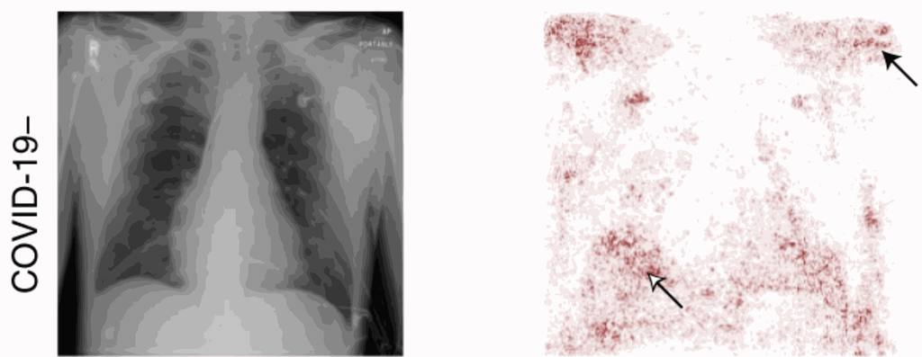

   Figure from DeGrave et al. (2021)

2. *Scientific Discovery*. In scientific applications our goal is often mechanistic understanding, not just predictive accuracy. For example, Labe and Barnes (2021) trained a model that predicts decade (e.g., 1970s or 2020s) from climate simulation outputs. Their saliency map method showed that the model focused on the north atlantic region when making these predictions.

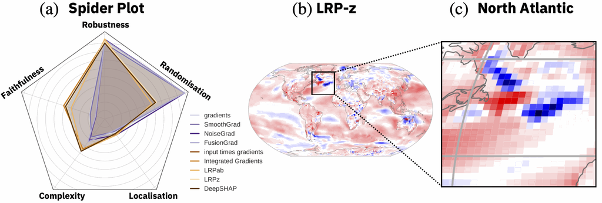

   Figure from Bommer et al. (2024).

3. *Need for Checks*. More generally, saliency maps can be used as a form of model checking and explanation. But as Adebayo et al. (2018) caution, this logic is not sufficient without additional checks. Some saliency methods highlight visually salient regions regardless of what the model has actually learned.
4. *Beyond Images*. Though we focus on images, gradient-based explanations apply to other types of data, e.g., see Yang and Ma (2023) for an application to genomic features or the captum tutorials on [text](https://captum.ai/tutorials/Llama2_LLM_Attribution) and [vision + text](https://captum.ai/tutorials/Multimodal_VQA_Interpret) explanations.

## Saliency Map Methods

1. *Gradient Explanation*. If the sample $x^\ast$ is predicted as class $k$, the simplest explanation is
   $$E_{\text{grad}}\left(x^*, f_{\theta}\right) = \nabla_{x}f_{\theta,k}\left(x^\ast\right),$$
   which measures how a small change to each input pixel changes the class $k$ probability. Pixels $d$ with the largest $\left[|E_{\text{grad},f_{\theta}}|\right]_{d}$ matter the most for the classification. Note that $\nabla_{x}f_{\theta,k}$ is a gradient with respect to the input, *not* the gradient $\nabla_{\theta}L\left(\theta\right)$ of the training loss with respect to the model parameters $\theta$, which is used during gradient descent training.

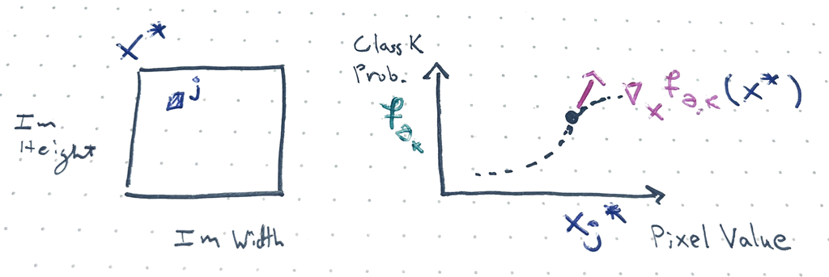

   Saliency measures class sensitivity to pixel perturbations.

   *Exercise: How would you modify this picture for a pixel that was in a nearly black region and which, when perturbed, makes no difference to the class $k$ prediction?*
2. *Input $\odot$ Gradient*. We can downweight the background by multiplying the gradient by the input elementwise,
   $$E_{\text{grad-input}}\left(x^*, f_{\theta}\right) = x^*\odot\nabla_{x}f_{\theta,k}\left(x^\ast\right).$$
   This suppresses attributions in the darker regions where $x ^\ast \approx 0$.

   *Exercise: What are the dimensions $E_{\text{grad}}$ and $E_{\text{grad-input}}$ when applied to a $W\times H$ image? How is that visualized as a saliency map?*

   *Exercise: The Input $\odot$ Gradient method always assigns zero attribution to pixels where $x^\ast_j = 0$.*
3. *Integrated Gradients*. The gradients of the softmax function vanish when the activations are large. Therefore, a confident model will have $\nabla_x f_{\theta, k}$ near zero even on important pixels. Integrated gradients address this by averaging over a path from a baseline $x_0$ (e.g., a black, all zeros image) to $x^\ast$,
   $$E_{\text{IG}}\left(x^*, f_{\theta}\right) = \int \nabla_{x}f_{\theta,k}\left(\alpha x^\ast +
   \left(1 - \alpha\right)x_{0}\right) d\alpha$$
   For intermediate values along this path, the activations are smaller and the gradients will not have yet saturated. In practice, we approximate this integral by a summation along a fine grid.

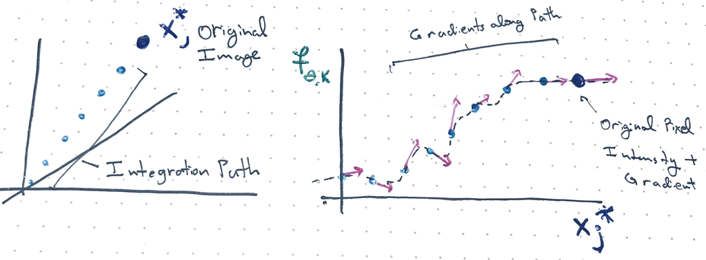

   Integrated gradients evaluates gradients along a path of shrunken images.

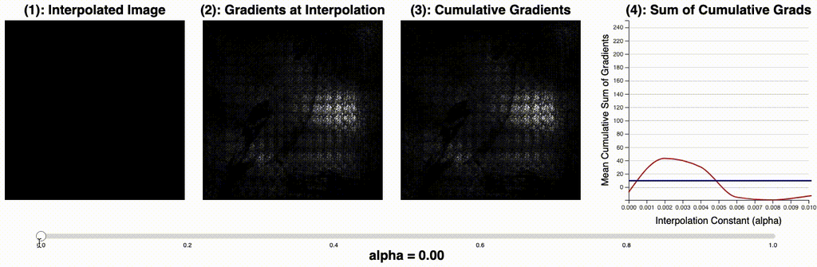

   Figure from Sturmfels et al. (2020)

4. *SmoothGrad* averages gradient explanations over noisy copies of the input,
   $$E_{\text{SG}}(x^*, f_{\theta}) = \frac{1}{B}\sum_{b = 1}^{B} E_{\text{grad}}\left(x^* + \epsilon_{b}, f_{\theta}\right), \quad \epsilon_{b} \sim \mathcal{N}(0, \sigma^2).$$
   This averaging results in smoother attribution maps.

   *Exercise: Compare and contrast one of these methods with SHAP.*

   *Exercise: TRUE FALSE The Integrated Gradients and Gradient approaches give the same saliency map for a linear model $f\left(x\right) = w^\top x$.*

## Sanity Checks

1. A key question is whether a saliency map depends on the trained model $f_{\theta}$ or only on the test image $x^\ast$. Adebayo et al. (2018) study two randomization tests to answer this. They can be viewed as negative controls – setups that deliberately have no signal and which serve as a reference point for interpretation.
2. **Model randomization** replaces trained weights with random weights layer by layer from top to bottom. Any structure in the explanation that we still observe reflects the model architecture, not what the model learned from the data. If this is the only structure we see in the original saliency map, the method fails the sanity check.

   ```
   Input:
     trained model f_θ with layers 1, ..., L (each with parameters θ^l)
     test input x*
     explanation method E(·, f_θ)   # e.g. gradient, integrated gradients,...
     similarity method Sim(E, E'), # e.g., Spearman correlation between pixel values

   # Baseline explanation on fully trained model
   E_original = E(x*, f_θ)
   explanations = [E_original]

   # Cascade from top layer down to bottom
   for l = L, L-1, ..., 1:
       θ^l ~ N(0, σ²) # randomize layer l
       E^(l) = E(x*, f_θ) # recompute explanation on partially-randomized model
       explanations.append(E^(l))

   # For each E^(l), return similarity to E_original
   similarities = [Sim(E^(l), E_original) for each E^(l) in explanations]
   ```

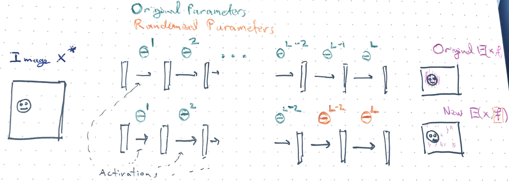

   Model randomization compares a genuine and a control explanation.

3. An explanation method passes if the similarity to the original degrades as more layers are randomized. The results show that Gradient and GradCam pass, but Guided BackProp and Guided GradCAM are nearly unchanged (their explanations are nearly the same in the training and randomized settings).

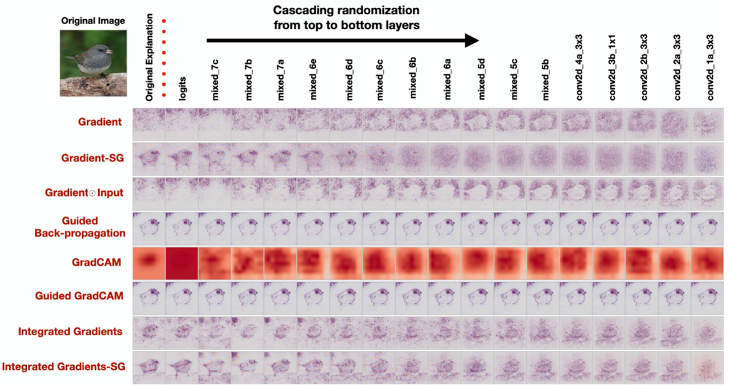

   *Exercise: Why is cascading randomization done from the top layer down? Why not randomize from the bottom layer up?*
4. A subtlety is that for some methods, the absolute value of the saliency map $\left|E\left(x^*, f_θ\right)\right|$ has high correlation with the original map $E\left(x^*, f_θ\right)$ after randomization, but the signed maps do not. Randomization breaks the sign of the attributions, but the magnitudes are a property of the original test image. Overall, quantitative checks matter here because saliency maps that look plausible to the eye can clearly fail under a quantitative measure like rank correlation.

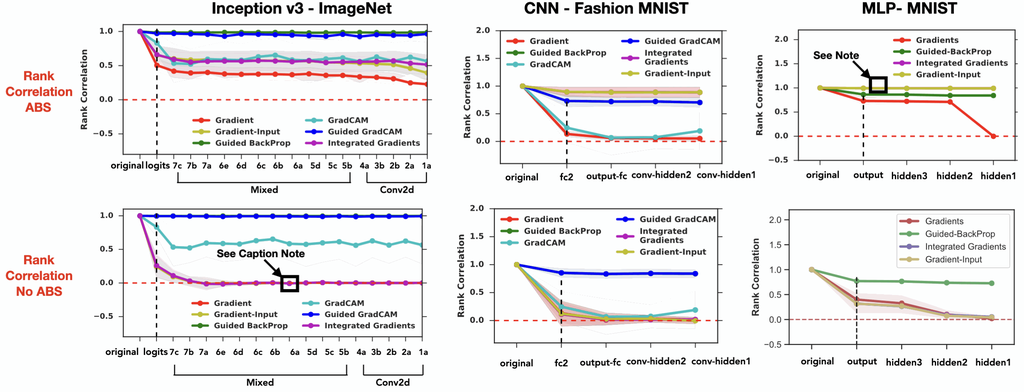

   *Exercise: Pick one of the panel from the figure above. Explain the associated experimental setup, how to read the output, and the implications for the saliency map methods that are considered.*
5. **Data randomization** Instead of corrupting the model, this negative control corrupts the data. Specifically, it permutes training labels $y_i$ and retrains to high accuracy on the training data (this is possible with flexible architectures, even if there is no signal). The model memorizes random associations, so any explanation that is sensitive to the true $x$ vs. $y$ relationships learned by $f_\theta$ should return a very different, random looking map after corruption.

   ```
   Input:
     training data {(x_i, y_i)}_{i=1}^{n}
     model architecture F
     test input x*
     explanation method E(·, f)
     similarity method Sim(E, E')

   # Train model on true labels
   f_true = train(A, {(x_i, y_i)})
   E_true = E(x*, f_true)

   # Permute labels and train on randomized data
   π = random_permute(1, ..., n)
   f_random = train(F, {(x_i, y_{π(i)})})   # train until 95% training accuracy on random labels
   E_random = E(x*, f_random)

   # Evaluate
   Sim(E_true, E_random)
   ```

   *Exercise: What are the relative compute costs for the two randomization tests? How do they scale with the samples?*
6. Again, Gradient and GradCAM pass the sanity check. Guided BackProp gives plausible results even in the corrupted case, so it fails. For Integrated Gradients, the signed maps change but the absolute value versions do not.

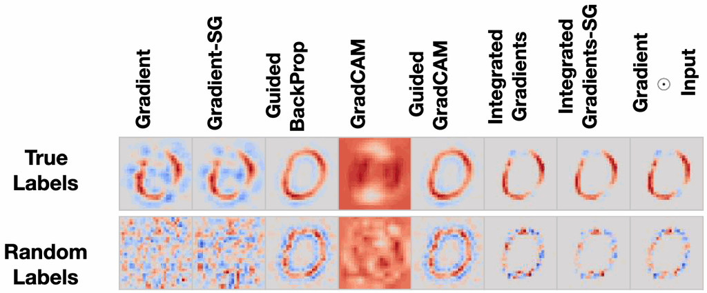

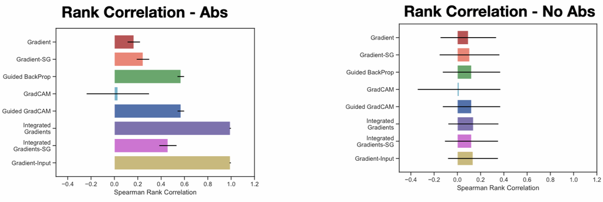

   *Exercise: For some models, we have access to the model’s architecture definition but not the model weights. Which if any of the sanity checks discussed by Adebayo et al. (2018) can still be used?*
7. The takeaway from this paper is that new explanation methods require the same methodological rigor that we apply when developing new models. Visual plausibility alone is not strong enough evidence.

## Code Example

1. We’ll use the `captum` package to create an integrated gradients saliency map using a pretrained ResNet18 model. The block below defines some helper functions for preprocessing and plotting.

   ```python
   import torch
   import numpy as np
   import pandas as pd
   import altair as alt
   from PIL import Image
   from torchvision import models, transforms
   from captum.attr import Saliency, IntegratedGradients

   def load_model():
    model = models.resnet18(weights=models.ResNet18_Weights.DEFAULT)
    model.eval()
    return model

   def preprocess(img):
    transform = transforms.Compose([
        transforms.Resize(256),
        transforms.CenterCrop(224),
        transforms.ToTensor(),
        transforms.Normalize(mean=[0.485, 0.456, 0.406],
                             std=[0.229, 0.224, 0.225]),
    ])
    return transform(img).unsqueeze(0).requires_grad_(True)

   def predict(model, input_tensor):
    with torch.no_grad():
        output = model(input_tensor)
    return output.argmax(dim=1).item()

   def attribution_to_df(tensor, label):
    """Flatten the (1, C, H, W) attribution tensor to a DataFrame."""
    arr = tensor.squeeze().abs().mean(dim=0).detach().numpy()
    h, w = arr.shape
    ys, xs = np.mgrid[0:h, 0:w]
    return pd.DataFrame({"x": xs.ravel(), "y": ys.ravel(),
                         "value": arr.ravel(), "method": label})
   ```

2. I took this image from wikimedia’s image of the day (March 24).

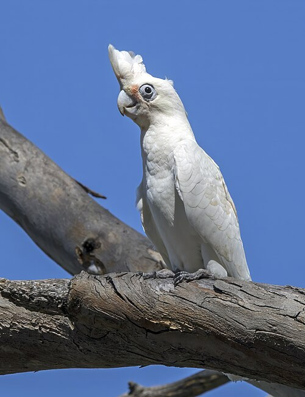

3. The pretrained Residual Network model correctly identifies the image as showing a type of cockatoo [Class 89](https://salient-imagenet.cs.umd.edu/explore/class_89/feature_675.html).

   ```python
   model = load_model()
   img = Image.open("figures/corella.jpg").convert("RGB")
   input_tensor = preprocess(img)
   target_class = predict(model, input_tensor)
   print(target_class)
   ```

   ```
   89
   ```

4. `Saliency` implements $E_{\text{grad}}\left(x^*, f_{\theta}\right)$, which is initialized on the trained model and applied to samples $x^*$.

   ```python
   saliency  = Saliency(model)
   attr_grad = saliency.attribute(input_tensor, target=target_class)
   ```

5. The `IntegratedGradients` interface is nearly the same except for `n_steps`, which controls how finely we should discretize the integration path.

   ```python
   ig = IntegratedGradients(model)
   attr_ig = ig.attribute(input_tensor, target=target_class, n_steps=50)
   ```

   ```python
   df = pd.concat([
    attribution_to_df(attr_grad, "Gradient Saliency"),
    attribution_to_df(attr_ig,   "Integrated Gradients"),
   ])

   chart = alt.Chart(df).mark_rect().encode(
    x=alt.X("x:O", axis=None),
    y=alt.Y("y:O", axis=None),
    color=alt.Color("value:Q")
   ).properties(width=200, height=200).facet(
    facet=alt.Facet("method:N", title=None),
    columns=2,
   ).configure_view(strokeWidth=0);
   ```

   ```
   664462
   ```

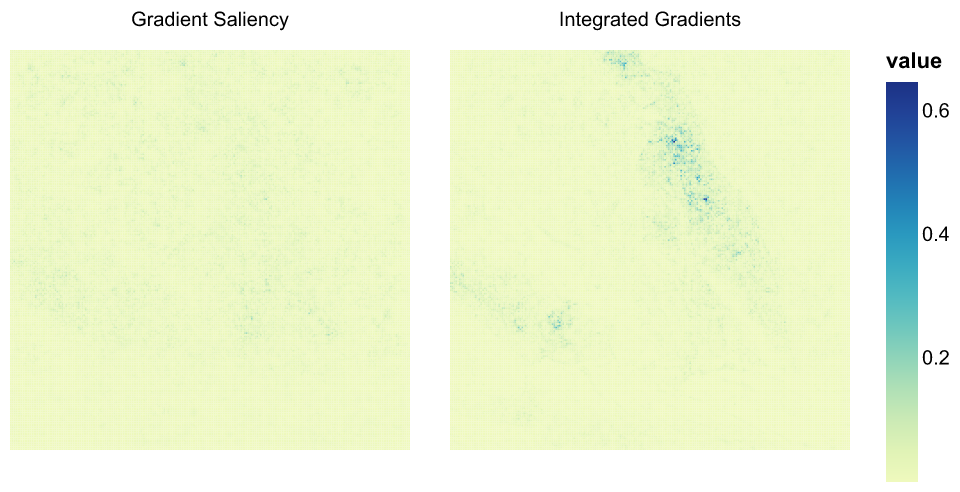

7. We next run the model randomization test, randomizing layers from the top down and computing the integrated gradients attribution at each step.

   ```python
   import copy
   from scipy.stats import spearmanr

   def attr_flat(attr):
    return attr.squeeze().abs().mean(dim=0).detach().numpy().ravel()

   cascade_layers = ["layer4", "layer3", "layer2", "layer1", "conv1"]
   layer_order = ["Original"] + [f"+ {l}" for l in cascade_layers]

   model_rand = copy.deepcopy(model)
   attrs = {"Original": attr_ig}
   for layer_name in cascade_layers:
    for param in model_rand.get_submodule(layer_name).parameters():
        torch.nn.init.normal_(param.data, std=0.1)
    attrs[layer_name] = IntegratedGradients(model_rand).attribute(input_tensor, target=target_class)
   ```

8. Even after the first layer, the Spearman correlations drop off.

   ```python
   orig_flat = attr_flat(attr_ig)
   cascade_dfs = [attribution_to_df(attr, layer_order[i]) for i, attr in enumerate(attrs.values())]
   [{"layer": l, "rank correlation": spearmanr(orig_flat, attr_flat(a)).statistic} for l, a in attrs.items()]
   ```

   We can see this effect in the visualizations. Even after randomizing the top layer, we no longer see the cockatoo appearing in the explanation.

   ```python
   df_cascade = pd.concat(cascade_dfs)

   chart = alt.Chart(df_cascade).mark_rect().encode(
    x=alt.X("x:O", axis=None),
    y=alt.Y("y:O", axis=None),
    color=alt.Color("value:Q")
   ).properties(width=150, height=150).facet(
    facet=alt.Facet("method:N", title=None, sort=layer_order),
    columns=3,
   );
   ```

   ```
   936239
   ```

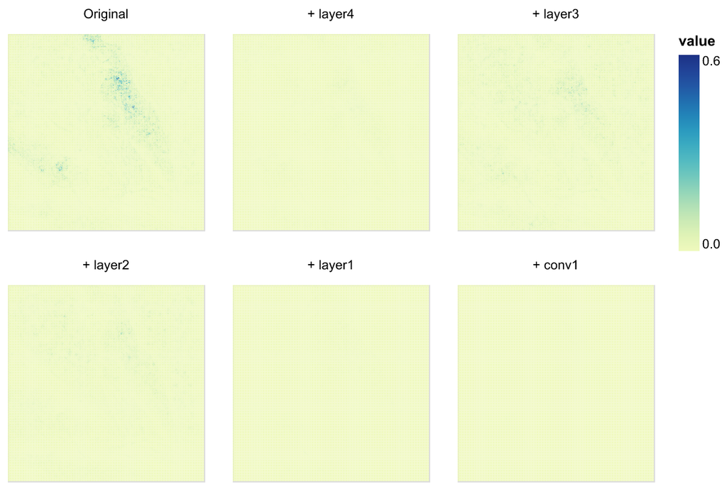

## References

Adebayo, Julius, Justin Gilmer, Michael Muelly, Ian Goodfellow, Moritz Hardt, and Been Kim. 2018. “Sanity Checks for Saliency Maps.” In *Advances in Neural Information Processing Systems*, edited by S. Bengio, H. Wallach, H. Larochelle, K. Grauman, N. Cesa-Bianchi, and R. Garnett, vol. 31. Curran Associates, Inc. https://proceedings.neurips.cc/paper_files/paper/2018/file/294a8ed24b1ad22ec2e7efea049b8737-Paper.pdf.

Bommer, Philine Lou, Marlene Kretschmer, Anna Hedström, Dilyara Bareeva, and Marina M.-C. Höhne. 2024. “Finding the Right XAI Method—a Guide for the Evaluation and Ranking of Explainable AI Methods in Climate Science.” *Artificial Intelligence for the Earth Systems* 3 (3). https://doi.org/10.1175/aies-d-23-0074.1.

DeGrave, Alex J., Joseph D. Janizek, and Su-In Lee. 2021. “AI for Radiographic COVID-19 Detection Selects Shortcuts over Signal.” *Nature Machine Intelligence* 3 (7): 610–19. https://doi.org/10.1038/s42256-021-00338-7.

Labe, Zachary M., and Elizabeth A. Barnes. 2021. “Detecting Climate Signals Using Explainable AI with Single‐forcing Large Ensembles.” *Journal of Advances in Modeling Earth Systems* 13 (6). https://doi.org/10.1029/2021ms002464.

Sturmfels, Pascal, Scott Lundberg, and Su-In Lee. 2020. “Visualizing the Impact of Feature Attribution Baselines.” *Distill* 5 (1). https://doi.org/10.23915/distill.00022.

Yang, Muyu, and Jian Ma. 2023. “UNADON: Transformer-Based Model to Predict Genome-Wide Chromosome Spatial Position.” *Bioinformatics* 39 (Supplement_1): i553–62. https://doi.org/10.1093/bioinformatics/btad246.